# Web Scraping: a tutorial in R

Ana I. Bento

1/13/2017

**Web Scraping** is a data mining technique to extract large amounts of data from websites. Also termed Screen Scraping, Web Data Extraction, Web Harvesting

[figure not shown]

## The `rvest` package in R

> 1. `rvest` is a package `(https://cran.r-project.org/web/packages/rvest/rvest.pdf)` that makes it easy to scrape (or *harvest*) data from html web pages
> 2. designed to work with `magrittr` and `xml2` so that you can express complex operations as elegant pipelines composed of simple, easily understood pieces
> 3. depending on the complexity of the tasks we will need additional packages

```r
#Install the package
#install.packages("rvest")
#Load the package
library(rvest)
```

**Checking if a website you want to “harvest” from is working**

```r
url=("https://scholar.google.com/citations?user=2NcJRZwAAAAJ&hl=en")
browseURL(url)
```

### Commands `read_html()`: Read in the webpage

```r
page <- read_html("https://scholar.google.com/citations?user=2NcJRZwAAAAJ&hl=en")
```

### Commands `html_nodes()` and `html_text()`: Specify the css selector in `html_nodes()` and extract the text with `html_text()`

**Get the citations on the first 20 papers on the page**

```r
citations <- page %>% html_nodes ("#gsc_a_b .gsc_a_c") %>% html_text()%>%as.numeric()
#Change the string to numeric using as.numeric()
```

**Plot the data**

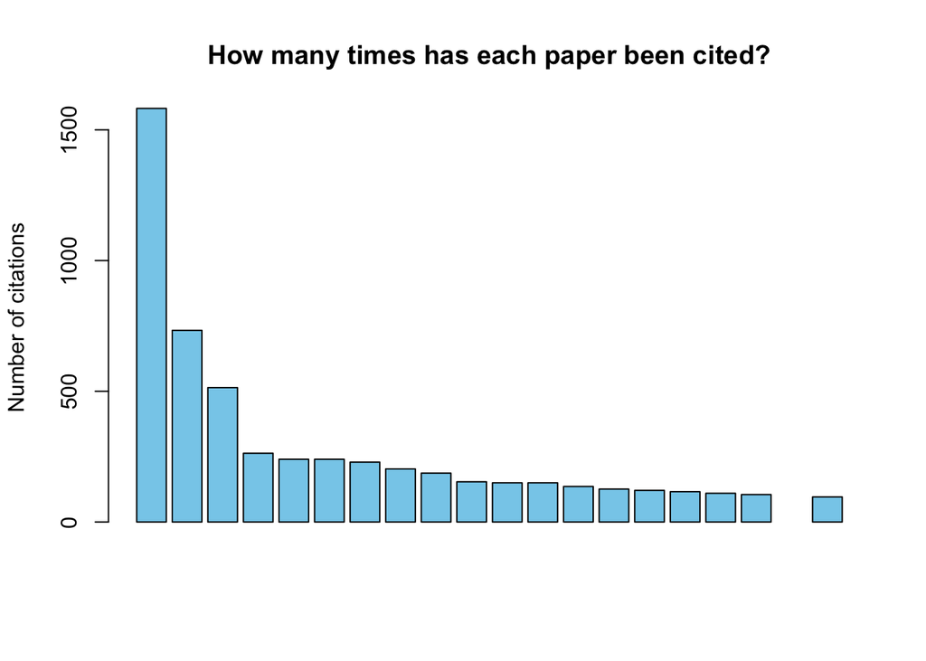

```r
barplot(citations, main="How many times has each paper been cited?", ylab='Number of citations', col="skyblue", xlab="")
```

**List the co-authors**

**NOTE:** `selectorgadget` for advanced css selecting: http://127.0.0.1:22088/library/rvest/doc/selectorgadget.html

```r
Coauthors = page%>% html_nodes(css=".gsc_rsb_aa") %>% html_text()
Coauthors = as.data.frame(Coauthors)
names(Coauthors)='Coauthors'
head(Coauthors)
```

```
##          Coauthors
## 1   Bryan Grenfell
## 2       David Earn
## 3    Aaron A. King
## 4   Matt J Keeling
## 5 Helen J. Wearing
## 6    John M. Drake
```

### Command `readLines`: Fetching raw data

The website is `http://stats.grok.se`: Wikipedia article traffic statistics

```r
var=201401
url=paste("http://stats.grok.se/json/en/",var,"/web_scraping",sep="")
raw.data <- readLines(url, warn="F")
raw.data
```

```
## [1] "{\"daily_views\": {\"2014-01-15\": 779, \"2014-01-14\": 806, \"2014-01-17\": 827, \"2014-01-16\": 981, \"2014-01-11\": 489, \"2014-01-10\": 782, \"2014-01-13\": 756, \"2014-01-12\": 476, \"2014-01-19\": 507, \"2014-01-18\": 473, \"2014-01-28\": 789, \"2014-01-29\": 799, \"2014-01-20\": 816, …
```

**Getting the JSON objects into R**

```r
#Intall rjson to convert JSON objects to R (JavaScript)
#install.packages("rjson")
require(rjson)
rd  <- fromJSON(raw.data)
head(rd)
```

```
## $daily_views
## $daily_views$`2014-01-15`
## [1] 779
##
## $daily_views$`2014-01-14`
## [1] 806
##
## $daily_views$`2014-01-17`
## [1] 827
##
## $daily_views$`2014-01-16`
## [1] 981
##
## $daily_views$`2014-01-11`
## [1] 489
##
## $daily_views$`2014-01-10`
## [1] 782
##
## $daily_views$`2014-01-13`
## [1] 756
##
## $daily_views$`2014-01-12`
## [1] 476
##
## $daily_views$`2014-01-19`
## [1] 507
##
## $daily_views$`2014-01-18`
## [1] 473
##
## $daily_views$`2014-01-28`
## [1] 789
##
## $daily_views$`2014-01-29`
## [1] 799
##
## $daily_views$`2014-01-20`
## [1] 816
##
```

[output cut: 51 more lines]

```
## $daily_views$`2014-01-30`
## [1] 1159
##
##
## $project
## [1] "en"
##
## $month
## [1] "201401"
##
## $rank
## [1] -1
##
## $title
## [1] "web_scraping"
```

**Rearranging the data and putting it all together**

```r
rd <- fromJSON(readLines(url, warn="F"))
rd.views <- rd$daily_views
rd.views <- unlist(rd.views)
df <- as.data.frame(rd.views)
df
```

```
##            rd.views
## 2014-01-15      779
## 2014-01-14      806
## 2014-01-17      827
## 2014-01-16      981
## 2014-01-11      489
## 2014-01-10      782
## 2014-01-13      756
## 2014-01-12      476
## 2014-01-19      507
## 2014-01-18      473
## 2014-01-28      789
## 2014-01-29      799
## 2014-01-20      816
## 2014-01-21      857
## 2014-01-22      899
## 2014-01-23      792
## 2014-01-24      749
## 2014-01-25      508
## 2014-01-26      488
## 2014-01-27      769
## 2014-01-06        0
## 2014-01-07      786
## 2014-01-04      456
## 2014-01-05       77
## 2014-01-02      674
## 2014-01-03      586
## 2014-01-01      348
## 2014-01-08      765
## 2014-01-09      787
## 2014-01-31      874
## 2014-01-30     1159
```

**Plotting the data**

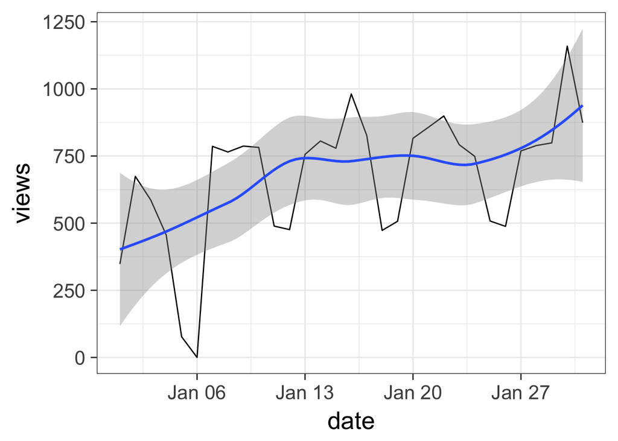

```r
suppressMessages(require(ggplot2))
suppressMessages(require(lubridate)) # parsing date-time data package
df$date <-  as.Date(rownames(df))
colnames(df) <- c("views","date")
ggplot(df,aes(date,views))+
  geom_line()+
  geom_smooth()+
  theme_bw(base_size=20)
```

### Command `html_table`: Making tables

#### Example 1

```r
    births <- read_html("https://www.ssa.gov/oact/babynames/numberUSbirths.html")
    html_table(html_nodes(births, "table")[[2]])
```

```
##     Year ofbirth      Male    Female     Total
## 1           1880   118,399    97,604   216,003
## 2           1881   108,282    98,855   207,137
## 3           1882   122,031   115,696   237,727
## 4           1883   112,478   120,059   232,537
## 5           1884   122,739   137,586   260,325
## 6           1885   115,946   141,949   257,895
## 7           1886   119,042   153,736   272,778
## 8           1887   109,315   155,422   264,737
## 9           1888   129,905   189,447   319,352
## 10          1889   119,034   189,219   308,253
## 11          1890   119,701   201,661   321,362
## 12          1891   109,267   196,567   305,834
## 13          1892   131,453   224,915   356,368
## 14          1893   121,040   225,232   346,272
```

[output cut: 122 more lines]

#### Example 2

```r
library(stringr) # package that manipulates that with strings
library(tidyr) # package that tidies data
url <- 'http://espn.go.com/nfl/superbowl/history/winners'
webpage <- read_html(url)
```

**These extract the HTML table element and convert it to a data frame**

```r
sb_table <- html_nodes(webpage, 'table')
sb <- html_table(sb_table)[[1]]
head(sb)
```

```
##                               X1                             X2
## 1 Super Bowl Winners and Results Super Bowl Winners and Results
## 2                            NO.                           DATE
## 3                              I                  Jan. 15, 1967
## 4                             II                  Jan. 14, 1968
## 5                            III                  Jan. 12, 1969
## 6                             IV                  Jan. 11, 1970
##                               X3                             X4
## 1 Super Bowl Winners and Results Super Bowl Winners and Results
## 2                           SITE                         RESULT
## 3  Los Angeles Memorial Coliseum   Green Bay 35, Kansas City 10
## 4            Orange Bowl (Miami)       Green Bay 33, Oakland 14
## 5            Orange Bowl (Miami)  New York Jets 16, Baltimore 7
## 6   Tulane Stadium (New Orleans)    Kansas City 23, Minnesota 7
```

**We remove the first two rows, and set the column name**

```r
sb <- sb[-(1:2), ]
names(sb) <- c("number", "date", "site", "result")
head(sb)
```

```
##   number          date                          site
## 3      I Jan. 15, 1967 Los Angeles Memorial Coliseum
## 4     II Jan. 14, 1968           Orange Bowl (Miami)
## 5    III Jan. 12, 1969           Orange Bowl (Miami)
## 6     IV Jan. 11, 1970  Tulane Stadium (New Orleans)
## 7      V Jan. 17, 1971           Orange Bowl (Miami)
## 8     VI Jan. 16, 1972  Tulane Stadium (New Orleans)
##                          result
## 3  Green Bay 35, Kansas City 10
## 4      Green Bay 33, Oakland 14
## 5 New York Jets 16, Baltimore 7
## 6   Kansas City 23, Minnesota 7
## 7       Baltimore 16, Dallas 13
## 8            Dallas 24, Miami 3
```

**We can convert the date to a standard format**

```r
sb$number <- 1:50
sb$date <- as.Date(sb$date, "%B. %d, %Y")
head(sb)
```

```
##   number       date                          site
## 3      1 1967-01-15 Los Angeles Memorial Coliseum
## 4      2 1968-01-14           Orange Bowl (Miami)
## 5      3 1969-01-12           Orange Bowl (Miami)
## 6      4 1970-01-11  Tulane Stadium (New Orleans)
## 7      5 1971-01-17           Orange Bowl (Miami)
## 8      6 1972-01-16  Tulane Stadium (New Orleans)
##                          result
## 3  Green Bay 35, Kansas City 10
## 4      Green Bay 33, Oakland 14
## 5 New York Jets 16, Baltimore 7
## 6   Kansas City 23, Minnesota 7
## 7       Baltimore 16, Dallas 13
## 8            Dallas 24, Miami 3
```

**We can split the results column into two columns at the comma**

```r
sb <- separate(sb, result, c('winner', 'loser'), sep=', ', remove=TRUE)
head(sb)
```

```
##   number       date                          site           winner
## 3      1 1967-01-15 Los Angeles Memorial Coliseum     Green Bay 35
## 4      2 1968-01-14           Orange Bowl (Miami)     Green Bay 33
## 5      3 1969-01-12           Orange Bowl (Miami) New York Jets 16
## 6      4 1970-01-11  Tulane Stadium (New Orleans)   Kansas City 23
## 7      5 1971-01-17           Orange Bowl (Miami)     Baltimore 16
## 8      6 1972-01-16  Tulane Stadium (New Orleans)        Dallas 24
##            loser
## 3 Kansas City 10
## 4     Oakland 14
## 5    Baltimore 7
## 6    Minnesota 7
## 7      Dallas 13
## 8        Miami 3
```

We split off the scores from the winner and loser columns. The function str_extract from the `stringr` package finds a substring matching a pattern. In this case, the pattern is a sequence of 1 or more digits at the end of a line.

```r
pattern <- " \\d+$"
sb$winnerScore <- as.numeric(str_extract(sb$winner, pattern))
sb$loserScore <- as.numeric(str_extract(sb$loser, pattern))
sb$winner <- gsub(pattern, "", sb$winner)
sb$loser <- gsub(pattern, "", sb$loser)
head(sb)
```

```
##   number       date                          site        winner
## 3      1 1967-01-15 Los Angeles Memorial Coliseum     Green Bay
## 4      2 1968-01-14           Orange Bowl (Miami)     Green Bay
## 5      3 1969-01-12           Orange Bowl (Miami) New York Jets
## 6      4 1970-01-11  Tulane Stadium (New Orleans)   Kansas City
## 7      5 1971-01-17           Orange Bowl (Miami)     Baltimore
## 8      6 1972-01-16  Tulane Stadium (New Orleans)        Dallas
##         loser winnerScore loserScore
## 3 Kansas City          35         10
## 4     Oakland          33         14
## 5   Baltimore          16          7
## 6   Minnesota          23          7
## 7      Dallas          16         13
## 8       Miami          24          3
```

**Writing a csv**

```r
write.csv(sb, 'superbowl.csv', row.names=F)
```

#### Example 3

**Like before html_table() command coerces the data into a data frame**

```r
suppressMessages(library(dplyr))     # data manipulation package
suppressMessages(library(reshape2))  # data reshape package
suppressMessages(library(googleVis)) # interactive plots package
webpage <- read_html("http://www.reed.edu/ir/geographic_states.html")
```

**The data we want is in the first table on this page**

```r
data1 <- webpage %>%
  html_nodes("table") %>%
  .[[1]] %>%
  html_table()
data1
```

```
##              State 2008 2009 2010 2011 2012 2013 2014 2015
## 1          Alabama    5    1    0    0    0    1    0    0
## 2           Alaska    0    3    1    3    3    2    2    1
## 3          Arizona    7    3    3    5    8    5    5    4
## 4         Arkansas    0    0    2    0    0    0    0    1
## 5       California   65   94   96   97   85   87   99  105
## 6         Colorado   14    5   11   13    7    7    3   11
## 7      Connecticut    7    5    9   13    7    3    4   15
## 8         Delaware    1    1    0    0    0    0    0    1
## 9   Washington, DC    7    5    6    2    1    3    4    0
## 10         Florida    9    5   10    4    4    9    2    9
## 11         Georgia    7    4    3    7    2    0    1    7
## 12          Hawaii    1    3    1    2    2    3    7    5
## 13           Idaho    2    2    3    3    2    4    3    7
## 14        Illinois    5    5   12    4    3   11    9   16
```

[output cut: 39 more lines]

**We can now work with this data from the web as a data frame in R**

```r
# remove total row from data
data1 <-
  data1 %>%
  filter(State!='Total')
```

**Reshape data for plotting**

```r
data_long <- melt(data1, id='State')
```

**Rename columns in long data frame**

```r
colnames(data_long) <- c('State', 'Year', 'Matriculants')
```

**Create and manipulate variables for plotting**

```r
data_long$Year <- as.numeric(as.character(data_long$Year))
data_long$year <- data_long$Year
data_long$state <- data_long$State
```

**Plot the data**

```r
Motion<-gvisMotionChart(data_long, "state", "year",
                yvar="Matriculants", xvar="Year",
                colorvar="State")
plot(Motion)
```

```
## starting httpd help server ...
```

```
##  done
```

### Command `html_text`: Extracting text

```r
htmlpage <- read_html("http://forecast.weather.gov/MapClick.php?lat=42.31674913306716&lon=-71.42487878862437&site=all&smap=1#.VRsEpZPF84I")
forecasthtml <- html_nodes(htmlpage, "#detailed-forecast-body b , .forecast-text")
forecast <- html_text(forecasthtml)
paste(forecast, collapse =" ")
```

```
## [1] "Tonight Rain, mainly after midnight.  Patchy fog after 1am. Low around 38. Light south wind increasing to 5 to 10 mph in the evening.  Chance of precipitation is 80%. New precipitation amounts between a tenth and quarter of an inch possible.  Thursday A chance of rain before 7am, then a chan…
```

## R package `tabulizer` for extracting data for PDF documents

### The `extract_tables` command

Accesses the any pdf file and extract all the tables

```r
#install.packages("ghit")
library(ghit)
#ghit::install_github(c("ropenscilabs/tabulizerjars", "ropenscilabs/tabulizer"))
library(tabulizer)
library(dplyr)
# Source the pdf file
location <- 'http://www.edd.ca.gov/jobs_and_training/warn/WARN-Report-for-7-1-2016-to-10-25-2016.pdf'
# Extract the table
out <- extract_tables(location)
```

We want to combine these into a single data matrix containing all of the data. We can do so most elegantly by combining `do.call` and `rbind`, passing it our list of matrices. Notice that I am excluding the last page here. The final page is the totals and summary information.

```r
final <- do.call(rbind, out[-length(out)])
```

```r
# table headers get extracted as rows with bad formatting. Dump them.
final <- as.data.frame(final[3:nrow(final), ])

# Column names
headers <- c('Notice.Date', 'Effective.Date', 'Received.Date', 'Company', 'City',
             'No.of.Employees', 'Layoff/Closure')

# Apply custom column names
names(final) <- headers
head(final)
```

```
##   Notice.Date Effective.Date Received.Date                Company
## 1  06/30/2016     08/31/2016   07/01/2016  DCS Facility Services
## 2  06/30/2016     08/31/2016   07/01/2016  DCS Facility Services
## 3  06/30/2016     08/31/2016   07/01/2016  DCS Facility Services
## 4  06/30/2016     08/31/2016   07/01/2016  DCS Facility Services
## 5  06/30/2016     08/31/2016   07/01/2016  DCS Facility Services
## 6  06/30/2016     08/31/2016   07/01/2016  DCS Facility Services
##           City No.of.Employees    Layoff/Closure
## 1    Antelope              55  Closure Permanent
## 2 Bakersfield              22  Closure Permanent
## 3   Brentwood              22  Closure Permanent
## 4       Chico              22  Closure Permanent
## 5      Clovis              33  Closure Permanent
## 6     Fontana              33  Closure Permanent
```

In order to manipulate the data properly , we will probably want to change the date column to a Date object as well as convert the No.of.Employees column to numeric. Here I do so using the R package `dplyr`.

```r
# These dplyr steps are not strictly necessary for dumping to csv, but useful if further data
# manipulation in R is required.
final <- final %>%
    # Convert date columns to date objects
    mutate_each(funs(as.Date(., format='%m/%d/%Y')), Notice.Date, Effective.Date, Received.Date) %>%
    # Convert No.of.Employees to numeric
    mutate(No.of.Employees = as.numeric(levels(No.of.Employees)[No.of.Employees]))

# Write final table to disk
write.csv(final, file='CA_WARN.csv', row.names=FALSE)
```

#### We can also specify specific pages and areas

```r
ab<-extract_tables('https://www.fia.com/sites/default/files/best_sector_times_17.pdf')
ab1<-extract_tables("http://www.fia.com/sites/default/files/external_archive/node4086/Race%20Lap%20Analysis.pdf", pages=8, guess=F, area=list(c(178, 10, 230, 500)))
write.csv(ab, 'abtable.csv', row.names=F)
```

If `guess = T` tabulizer figures out the locations of the tables on its own Using a combination of “guess” to find the dominant table, and specified areas, we can extract the data we need from the PDF and combine it to provide a structured and clearly labeled dataframe.

[figure not shown]